# Predicting Colorectal Cancer Using Gut Microbiome Profiles

Mohit Batra

2025-08-02

# Project Overview

This project aims to develop a machine learning (ML) model capable of predicting disease status (Colorectal Cancer vs. Healthy) based on gut microbiome profiles derived from metagenomic sequencing data. By using microbiome-derived features, we explore how microbial community composition can serve as a biomarker for colorectal cancer (CRC) and contribute to non-invasive diagnostic strategies.

We use a dataset from Feng et al., 2015, one of the earliest large-scale Metagenome-Wide Association Studies (MGWAS) on colorectal cancer. The study provides gut microbial abundance data and clinical metadata for healthy individuals and patients with adenoma or carcinoma. Our analysis focuses on distinguishing carcinoma from healthy samples using gut microbial gene family profiles.

# Environmental Setup

To begin the analysis, we load all the required R packages. These will handle everything from data wrangling to machine learning and plotting. We also set a random seed to ensure reproducibility of results.

```r
# Load required libraries
suppressPackageStartupMessages({
  library(tidyverse)        # For data manipulation and visualization
  library(readr)            # Efficient reading of CSV files
  library(caret)            # Machine learning framework and cross-validation
  library(randomForest)     # Random Forest classifier
  library(pROC)             # ROC curve and AUC calculation
  library(ggplot2)          # Core plotting system
  library(cowplot)          # For combining ggplot2 plots
  library(RColorBrewer)     # Color palettes
  library(reshape2)         # Data reshaping
  library(corrplot)         # Correlation plots
  library(here)             # For directory management
  library(compositions)       # For CLR transformation
})
```

We now set the random seed to make sure our results are reproducible, especially the machine learning parts.

```r
set.seed(42)
```

Next, we define our working directory structure. This keeps things clean and modular. If the necessary folders don’t exist (such as the folder for saving plots), they are created automatically.

```r
# Define project paths
project_dir <- here::here()
data_dir <- file.path(project_dir, "data")
results_dir <- file.path(project_dir, "results")
figures_dir <- file.path(results_dir, "figures")

# Create results/figures directory if it doesn't exist
if (!dir.exists(figures_dir)) {
  dir.create(figures_dir, recursive = TRUE)
}
```

We now load the processed count matrix and metadata file. These were previously saved as CSV files. We use `readr::read_csv()` for efficient and clean parsing.

```r
# Load count and metadata tables
counts <- read.csv(file.path(data_dir, "counts.csv"), header = T,row.names = 1)
metadata <- read_csv(file.path(data_dir, "metadata.csv"))
```

```r
head(metadata)
```

```
## # A tibble: 6 × 11
##   subject_id study_condition   age age_category gender NCBI_accession        BMI
##   <chr>      <chr>           <dbl> <chr>        <chr>  <chr>               <dbl>
## 1 SID31004   CRC                64 adult        male   ERR688505;ERR688358  29.4
## 2 SID31009   control            68 senior       male   ERR688506;ERR688359  32
## 3 SID31021   control            60 adult        female ERR688507;ERR688360  22.1
## 4 SID31030   adenoma            70 senior       male   ERR688508;ERR688361  34.1
## 5 SID31071   control            68 senior       male   ERR688509;ERR688362  23.4
## 6 SID31112   control            66 senior       male   ERR688510;ERR688363  30.3
## # ℹ 4 more variables: diet <chr>, hdl <dbl>, ldl <dbl>, triglycerides <dbl>
```

```r
head(counts)[1:5,1:5]
```

```
##                                                SID31004    SID31009    SID31021
## UNMAPPED                                    0.185320000 0.283803000 0.204240000
## UniRef90_A7B5X2                             0.000674853 0.000604870 0.000611847
## UniRef90_A5ZYU5                             0.000844908 0.000819948 0.000980607
## UniRef90_A5ZYU5|g__Blautia.s__Blautia_obeum 0.000844834 0.000819788 0.000980607
## UniRef90_A5ZYU0                             0.000749945 0.000549261 0.000667191
##                                                SID31030    SID31071
## UNMAPPED                                    0.253765000 0.216060000
## UniRef90_A7B5X2                             0.000734353 0.000915965
## UniRef90_A5ZYU5                             0.000395016 0.001451610
## UniRef90_A5ZYU5|g__Blautia.s__Blautia_obeum 0.000394918 0.001451610
## UniRef90_A5ZYU0                             0.000498813 0.000971019
```

# Data Preprocessing

In this step, we ensure that the count matrix and metadata are aligned and ready for downstream machine learning. We clean the data, match sample IDs, and transform the count matrix for classification.

We’ll first ensure that both metadata and count tables have consistent sample identifiers. We also set sample IDs as row names for easy alignment.

```r
# Set sample IDs as row names
metadata <- metadata %>% column_to_rownames(var = "subject_id")
```

```r
# Transpose the count matrix to have samples as rows
counts_t <- as.data.frame(t(counts))

# Filter out taxa with low prevalence across samples
prevalence_threshold <- 0.1  # keep taxa present in at least 10% of samples
keep_taxa <- colSums(counts_t > 0) > (nrow(counts_t) * prevalence_threshold)
counts_filtered <- counts_t[, keep_taxa]

# Add pseudocount to avoid log(0) issues
counts_filtered <- counts_filtered + 1

# Perform CLR transformation
clr_counts <- as.data.frame(clr(counts_filtered))

# Sanity check: match sample IDs with metadata
clr_counts$sample_id <- rownames(clr_counts)
metadata$sample_id <- rownames(metadata)

# Merge metadata and CLR-transformed counts
merged_data <- inner_join(metadata[,c("study_condition", "sample_id")], clr_counts, by = "sample_id")

# Filter out adenoma samples from metadata and counts
filtered_data <- merged_data %>%
  filter(study_condition %in% c("control", "CRC"))

# Final prep for ML
X <- filtered_data %>% select(-sample_id, -study_condition)
y <- as.factor(filtered_data$study_condition)
```

# Data Partitioning & Model Training & Evaluation

We split the data into 80% training and 20% test sets, apply cross-validation on the training set, and evaluate final performance on the independent test set. This gives a more reliable estimate of how well the model generalizes.

```r
set.seed(42)
train_idx <- caret::createDataPartition(y, p = 0.8, list = FALSE)

X_train <- X[train_idx, ]
X_test  <- X[-train_idx, ]
y_train <- y[train_idx]
y_test  <- y[-train_idx]
```

```r
# cross-validation strategy with 5 folds
ctrl <- trainControl(
  method = "cv",
  number = 5,
  classProbs = TRUE,
  summaryFunction = twoClassSummary,
  verboseIter = FALSE
)

# Train the Random Forest model
rf_model <- caret::train(
  x = X_train,
  y = y_train,
  method = "rf",
  trControl = ctrl,
  metric = "ROC",
  importance = TRUE
)
```

```r
set.seed(42)
# Predict class probabilities and labels on the test set
pred_probs <- predict(rf_model, X_test, type = "prob")
pred_class <- predict(rf_model, X_test)

# Confusion Matrix
conf_matrix <- confusionMatrix(pred_class, y_test)
print(conf_matrix)
```

```
## Confusion Matrix and Statistics
##
##           Reference
## Prediction control CRC
##    control       9   3
##    CRC           3   6
##
##                Accuracy : 0.7143
##                  95% CI : (0.4782, 0.8872)
##     No Information Rate : 0.5714
##     P-Value [Acc > NIR] : 0.1345
##
##                   Kappa : 0.4167
##
##  Mcnemar's Test P-Value : 1.0000
##
##             Sensitivity : 0.7500
##             Specificity : 0.6667
##          Pos Pred Value : 0.7500
##          Neg Pred Value : 0.6667
##              Prevalence : 0.5714
##          Detection Rate : 0.4286
##    Detection Prevalence : 0.5714
##       Balanced Accuracy : 0.7083
##
##        'Positive' Class : control
##
```

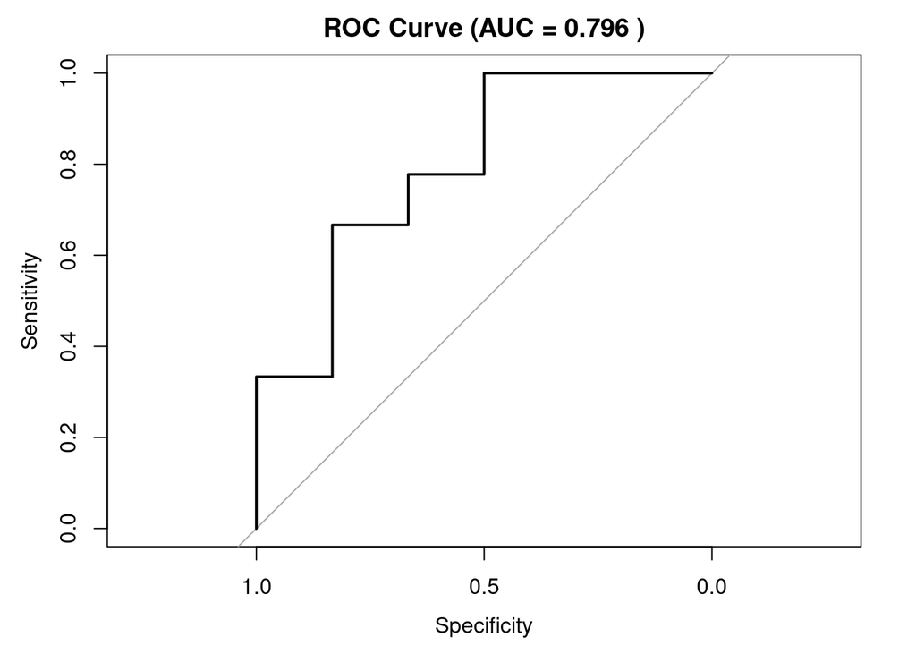

```r
# ROC Curve and AUC
roc_obj <- roc(response = y_test, predictor = pred_probs[, "CRC"])  # Adjust label if needed
auc_val <- auc(roc_obj)

# Plot ROC Curve
plot(roc_obj, main = paste("ROC Curve (AUC =", round(auc_val, 3), ")"))
```

## Initial Results Interpretation

The ROC curve (above) demonstrates a clear separation from the no-skill classifier (diagonal line), suggesting that microbiome profiles encode meaningful biological signals relevant to colorectal cancer status. However, the performance is not optimal and leaves room for further improvement.

Several factors may limit this model’s accuracy:

- High dimensionality of microbial features vs. sample size
- Class imbalance (after removing adenoma samples)
- Lack of additional clinical covariates (e.g., diet, age)

These results support the feasibility of microbiome-based classification, but also justify a subsequent model tuning phase to enhance robustness and predictive accuracy.

# Model Optimization

To improve classification performance, we now perform hyperparameter tuning on the Random Forest model. Specifically, we tune the `mtry` parameter, which controls the number of features randomly selected at each split in the trees.

We use 10-fold cross-validation to estimate model performance during tuning.

## Prepare for training

```r
# Define training control
train_control <- caret::trainControl(
  method = "cv",         # Cross-validation
  number = 10,           # Number of folds
  classProbs = TRUE,     # Needed for AUC
  summaryFunction = twoClassSummary,  # Use AUC for model evaluation
  savePredictions = TRUE
)

# Recode y_train as "Healthy" vs "Cancer" (caret prefers string labels)
y_train_binary <- factor(ifelse(y_train == "control", "Healthy", "Cancer"))

# Combine features and labels into one training set
training_data <- cbind(y_train_binary, X_train)
colnames(training_data)[1] <- "Condition"
```

## Train the tuned model

```r
# Train the model with tuning
set.seed(42)
rf_tuned <- caret::train(
  Condition ~ .,
  data = training_data,
  method = "rf",
  metric = "ROC",                  # Optimize for AUC
  trControl = train_control,
  tuneGrid = expand.grid(mtry = c(1, 2, 3, 5, 10))  # Try different mtry values
)
```

```r
# Print best model info
print(rf_tuned)
```

```
## Random Forest
##
##  86 samples
## 500 predictors
##   2 classes: 'Cancer', 'Healthy'
##
## No pre-processing
## Resampling: Cross-Validated (10 fold)
## Summary of sample sizes: 78, 77, 78, 77, 77, 78, ...
## Resampling results across tuning parameters:
##
##   mtry  ROC        Sens       Spec
##    1    0.6633333  0.4750000  0.80
##    2    0.6475000  0.5083333  0.74
##    3    0.6466667  0.4500000  0.74
##    5    0.6725000  0.5000000  0.78
##   10    0.6891667  0.5083333  0.74
##
## ROC was used to select the optimal model using the largest value.
## The final value used for the model was mtry = 10.
```

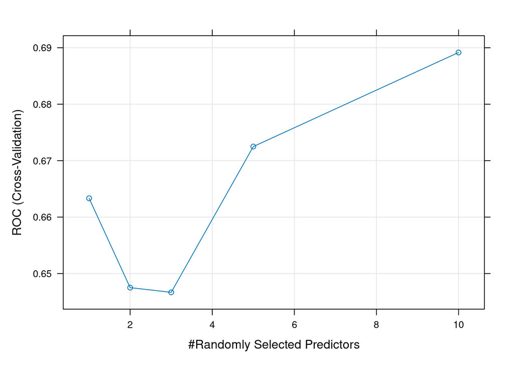

```r
plot(rf_tuned)
```

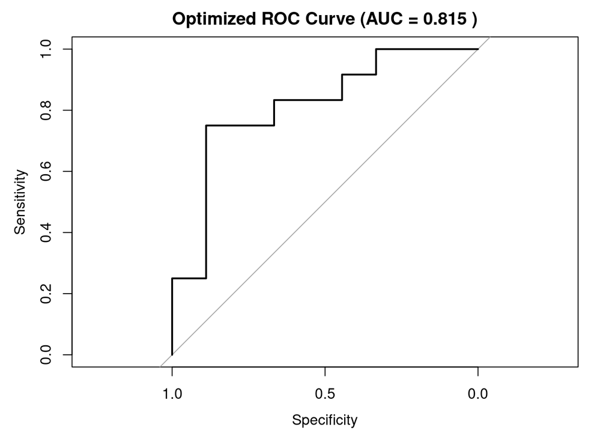

```r
# Predict probabilities on the test set
x_test_matrix <- X_test  # make sure it's in same format
rf_probs <- predict(rf_tuned, newdata = x_test_matrix, type = "prob")

# Recode test labels to match training (Healthy/Cancer)
y_test_binary <- factor(ifelse(y_test == "control", "Healthy", "Cancer"))

# Generate ROC curve
rf_roc <- roc(response = y_test_binary, predictor = rf_probs$Cancer)
# Plot ROC
plot(rf_roc, main = paste("Optimized ROC Curve (AUC =", round(auc(rf_roc), 3), ")"))
```

## Future Importance

```r
# Extract variable importance
importance_vals <- varImp(rf_tuned)$importance
importance_vals$Taxon <- rownames(importance_vals)
```

We need a function to clean the taxa names:

```r
clean_taxa_names <- function(taxa_names, keep_uniref = FALSE) {
  cleaned <- gsub(".*\\|g__", "", taxa_names)                          # Remove prefix up to genus
  cleaned <- gsub("s__", "", cleaned)                                 # Remove species label
  cleaned <- gsub("`", "", cleaned)                                   # Remove backticks
  cleaned <- gsub("_", " ", cleaned)                                  # Replace underscores with spaces
  cleaned <- trimws(cleaned)                                          # Trim whitespace

  # Optionally keep UniRef ID for traceability
  if (keep_uniref) {
    ids <- sub("\\|.*", "", taxa_names)                               # Extract UniRef ID
    cleaned <- paste0(cleaned, " (", ids, ")")                        # Append ID
  }

  return(cleaned)
}
```

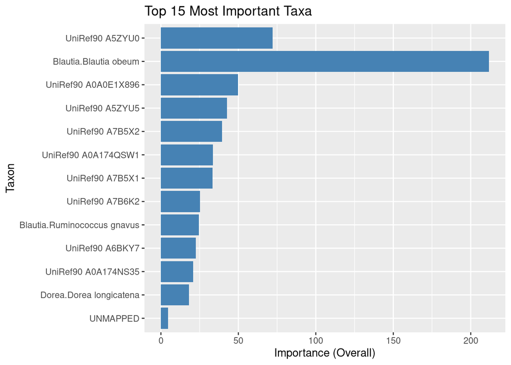

```r
original_names <- importance_vals$Taxon  # or rownames(importance)
importance_vals$Taxon_clean <- clean_taxa_names(original_names, keep_uniref = FALSE)

# Use Taxon_clean in your ggplot
ggplot(importance_vals[1:15, ], aes(x = reorder(Taxon_clean, Overall), y = Overall)) +
  geom_bar(stat = "identity", fill = "steelblue") +
  coord_flip() +
  labs(title = "Top 15 Most Important Taxa", x = "Taxon", y = "Importance (Overall)")
```

# Conclusion

In this project, we developed a machine learning pipeline to classify colorectal cancer (CRC) status based on gut microbiome composition using metagenomic data from the FengQ_2015 study. Leveraging CLR-transformed microbial count data, we implemented and optimized a Random Forest classifier to distinguish colorectal cancer patients from healthy controls.

The initial model achieved a moderate AUC of 0.796, which improved to 0.815 after hyperparameter tuning, indicating a meaningful relationship between microbiome composition and disease status.

This analysis supports the growing body of evidence that the gut microbiome contains predictive signals for colorectal cancer and can serve as a non-invasive biomarker source for early disease screening. However, given the small sample size and class imbalance, these results should be considered preliminary. Future improvements could involve:

Additionally, expanding the analysis to include adenoma samples, or integrating dietary and lifestyle metadata, may enhance both interpretability and predictive accuracy in real-world screening applications.